# hw1-sandra-zavala.

```r
library(tidyverse)
```

## 1) Data `storms`

The data file for this lab has to do with Storms. The dataset is part of the `dplyr` package: `storms`.`

```r
storms
```

| name | year | month | day | hour | lat | long | status | category | wind | pressure | ts_diameter | hu_diameter |
| --- | --- | --- | --- | --- | --- | --- | --- | --- | --- | --- | --- | --- |
| Amy | 1975 | 6 | 27 | 0 | 27.5 | -79.0 | tropical depression | -1 | 25 | 1013 | NA | NA |
| Amy | 1975 | 6 | 27 | 6 | 28.5 | -79.0 | tropical depression | -1 | 25 | 1013 | NA | NA |
| Amy | 1975 | 6 | 27 | 12 | 29.5 | -79.0 | tropical depression | -1 | 25 | 1013 | NA | NA |
| Amy | 1975 | 6 | 27 | 18 | 30.5 | -79.0 | tropical depression | -1 | 25 | 1013 | NA | NA |
| Amy | 1975 | 6 | 28 | 0 | 31.5 | -78.8 | tropical depression | -1 | 25 | 1012 | NA | NA |
| Amy | 1975 | 6 | 28 | 6 | 32.4 | -78.7 | tropical depression | -1 | 25 | 1012 | NA | NA |
| Amy | 1975 | 6 | 28 | 12 | 33.3 | -78.0 | tropical depression | -1 | 25 | 1011 | NA | NA |
| Amy | 1975 | 6 | 28 | 18 | 34.0 | -77.0 | tropical depression | -1 | 30 | 1006 | NA | NA |
| Amy | 1975 | 6 | 29 | 0 | 34.4 | -75.8 | tropical storm | 0 | 35 | 1004 | NA | NA |
| Amy | 1975 | 6 | 29 | 6 | 34.0 | -74.8 | tropical storm | 0 | 40 | 1002 | NA | NA |

[output cut: 9990 more lines]

## 2) Storms in 2015

### a) Write a “dplyr” command to create a table (i.e. tibble) storms2015 containing the storms that took place in the year 2015.

```r
storms2015 <- filter(storms, year == 2015)
storms2015
```

| name | year | month | day | hour | lat | long | status | category | wind | pressure | ts_diameter | hu_diameter |
| --- | --- | --- | --- | --- | --- | --- | --- | --- | --- | --- | --- | --- |
| Ana | 2015 | 5 | 9 | 6 | 32.2 | -77.5 | tropical storm | 0 | 50 | 998 | 230.1560 | 0.0000 |
| Ana | 2015 | 5 | 9 | 12 | 32.5 | -77.8 | tropical storm | 0 | 50 | 1001 | 230.1560 | 0.0000 |
| Ana | 2015 | 5 | 9 | 18 | 32.7 | -78.0 | tropical storm | 0 | 45 | 1001 | 230.1560 | 0.0000 |
| Ana | 2015 | 5 | 10 | 0 | 33.1 | -78.3 | tropical storm | 0 | 45 | 1001 | 184.1248 | 0.0000 |
| Ana | 2015 | 5 | 10 | 6 | 33.5 | -78.6 | tropical storm | 0 | 40 | 1002 | 172.6170 | 0.0000 |
| Ana | 2015 | 5 | 10 | 10 | 33.8 | -78.8 | tropical storm | 0 | 40 | 1002 | 172.6170 | 0.0000 |
| Ana | 2015 | 5 | 10 | 12 | 33.9 | -78.8 | tropical storm | 0 | 35 | 1002 | 149.6014 | 0.0000 |
| Ana | 2015 | 5 | 10 | 18 | 34.3 | -78.7 | tropical depression | -1 | 30 | 1006 | 0.0000 | 0.0000 |
| Ana | 2015 | 5 | 11 | 0 | 34.7 | -78.5 | tropical depression | -1 | 30 | 1009 | 0.0000 | 0.0000 |
| Ana | 2015 | 5 | 11 | 6 | 35.5 | -78.0 | tropical depression | -1 | 30 | 1010 | 0.0000 | 0.0000 |

[output cut: 210 more lines]

### b) With storms2015, write a command that returns only the name of unique storms in 2015. In other words, the output should display only the unique names and nothing else.

```r
unique(pull(storms2015, name))
```

```
##  [1] "Ana"       "Bill"      "Claudette" "Danny"     "Erika"     "Fred"
##  [7] "Henri"     "Nine"      "Ida"       "Joaquin"   "Kate"
```

### c) With storms2015, write a command that returns a table with the name of each unique storm and the number of times it appears. In other words, this is a table with two columns: 1) name of storm, and 2) the number of counts of each storm.

```r
count(storms2015, name)
```

| name | n |
| --- | --- |
| Ana | 12 |
| Bill | 12 |
| Claudette | 7 |
| Danny | 26 |
| Erika | 16 |
| Fred | 31 |
| Henri | 11 |
| Ida | 37 |
| Joaquin | 42 |
| Kate | 13 |

[output cut: 1 more lines]

### d) With storms2015, write a command that gives you the name, month and day of the first storm recorded in 2015.

```r
head(select((storms2015 %>% arrange(month, day, hour)), name, month, day),1)
```

| name | month | day |
| --- | --- | --- |
| Ana | 5 | 9 |

### e) With storms2015, write a command that gives you the number of hurricanes that occurred in 2015. Hint: How does a storm acquire hurricane status? (category 3+)

```r
count((filter(storms2015, category >= 3)))
```

| n |
| --- |
| 18 |

### f) With storms2015, write a command that gives you the names of the hurricanes that occurred during that year. Hint: How does a storm acquire hurricane status?

```r
unique(pull((filter(storms2015, category >= 3)), name))
```

```
## [1] "Danny"   "Joaquin"
```

## 3) More manipulation

1. Use “dplyr” functions/commands to create a table (e.g. tibble) storm_names_2010s containing columns name and year of storms recorded from 2010 to 2015. To clarify, this table should contain only one occurrence of each storm. Use head() and tail() to display its first 5 rows, and also its last 5 rows.

```r
storm_names_2010s <- distinct(select(filter(storms, year == 2010 | year == 2011 | year == 2012 | year == 2013 | year == 2014 | year == 2015), name, year))
storm_names_2010s
```

| name | year |
| --- | --- |
| Alex | 2010 |
| Two | 2010 |
| Bonnie | 2010 |
| Colin | 2010 |
| Five | 2010 |
| Danielle | 2010 |
| Fiona | 2010 |
| Gaston | 2010 |
| Hermine | 2010 |
| Igor | 2010 |

[output cut: 74 more lines]

```r
first_five <- head(storm_names_2010s, 5)
last_five <- tail(storm_names_2010s, 5)

first_five
```

| name | year |
| --- | --- |
| Alex | 2010 |
| Two | 2010 |
| Bonnie | 2010 |
| Colin | 2010 |
| Five | 2010 |

```r
first_five <- head(storm_names_2010s, 5)
last_five <- tail(storm_names_2010s, 5)

last_five
```

| name | year |
| --- | --- |
| Henri | 2015 |
| Nine | 2015 |
| Ida | 2015 |
| Joaquin | 2015 |
| Kate | 2015 |

2. With the entire storms data, use “dplyr” functions/commands to create a table (or tibble) storm_counts_per_year containing the number of unique storms in each year (i.e. counts of storms in each year). This table should contain two columns: year values in the first column, and the number of unique storms in the second column. Display its last 15 rows.

```r
storm_counts_per_year <- count(group_by(distinct(select(storms, name, year)), year))
tail(storm_counts_per_year, 15)
```

| year | n |
| --- | --- |
| 2001 | 17 |
| 2002 | 12 |
| 2003 | 20 |
| 2004 | 13 |
| 2005 | 21 |
| 2006 | 9 |
| 2007 | 16 |
| 2008 | 14 |
| 2009 | 10 |
| 2010 | 20 |

[output cut: 5 more lines]

3. With the entire storms data, use “dplyr” functions/commands to create a table (e.g. tibble) max_wind_per_storm containing three columns: 1) year of storm, 2) name of storm, and 3) max_wind maximum wind speed record (for that storm). Display its first 10 rows, and also its last 10 rows

```r
max_wind_per_storm <- summarise(
  group_by(storms, name, year),
  max_wind = max(wind))
max_wind_per_storm
```

| name | year | max_wind |
| --- | --- | --- |
| AL011993 | 1993 | 30 |
| AL012000 | 2000 | 25 |
| AL021992 | 1992 | 30 |
| AL021994 | 1994 | 30 |
| AL021999 | 1999 | 30 |
| AL022000 | 2000 | 30 |
| AL022001 | 2001 | 25 |
| AL022003 | 2003 | 30 |
| AL022006 | 2006 | 45 |
| AL031987 | 1987 | 40 |

[output cut: 416 more lines]

```r
first_ten <- head(max_wind_per_storm, 10)
last_ten <- tail(max_wind_per_storm, 10)

first_ten
```

| name | year | max_wind |
| --- | --- | --- |
| AL011993 | 1993 | 30 |
| AL012000 | 2000 | 25 |
| AL021992 | 1992 | 30 |
| AL021994 | 1994 | 30 |
| AL021999 | 1999 | 30 |
| AL022000 | 2000 | 30 |
| AL022001 | 2001 | 25 |
| AL022003 | 2003 | 30 |
| AL022006 | 2006 | 45 |
| AL031987 | 1987 | 40 |

```r
last_ten
```

| name | year | max_wind |
| --- | --- | --- |
| Ten | 2007 | 30 |
| Ten | 2011 | 30 |
| Tomas | 2010 | 85 |
| Tony | 2012 | 45 |
| Two | 2010 | 30 |
| Two | 2014 | 30 |
| Vince | 2005 | 65 |
| Wilma | 2005 | 160 |
| Zeta | 2005 | 50 |
| Zeta | 2006 | 55 |

##4) Some basic plots with “ggplot2” a) Make a barchart for the number of (unique) storms in each year during the period 2010 to 2015. Make sure that the axis-label of each bar indicates the associated year. Also, add a meaningful title to the plot.

```r
storm2010_15 <- filter(storms, year == 2010 | year == 2011 | year == 2012 | year == 2013 | year == 2014 | year == 2015)
uniquestorm2010_15 <- summarise(group_by(storm2010_15,year), number = n())
uniquestorm2010_15
```

| year | number |
| --- | --- |
| 2010 | 402 |
| 2011 | 323 |
| 2012 | 454 |
| 2013 | 202 |
| 2014 | 139 |
| 2015 | 220 |

[figure not shown]

```r
ggplot(data=uniquestorm2010_15, aes(x=factor(year), y=number)) +
  geom_bar(stat="identity", color= "black", fill= "lightsalmon") + ggtitle('Storm Count by Year from 2010 - 2015')
```

2. Using the entire storms table, make a density graph for the variable wind, adding color to the border line, as well as the filling color of the density curve. Also, add a meaningful title to the plot, and choose the “Black-White” theme for the background of the graph.

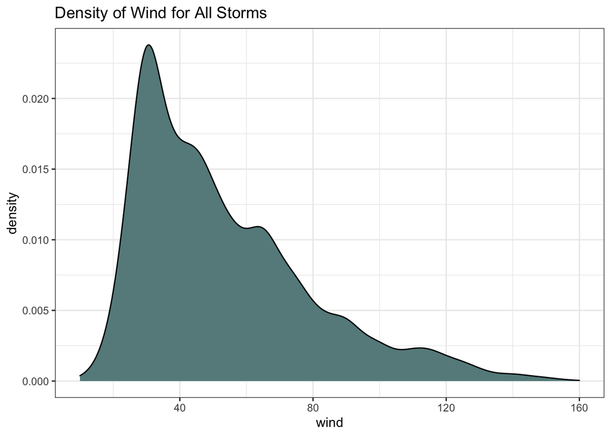

```r
ggplot(data=storms, aes(x=wind)) + geom_density(fill='paleturquoise4') +  ggtitle('Density of Wind for All Storms') + theme_bw() + scale_color_brewer(palette="Dark2")
```

3. Make boxplots for the variable pressure of storms in each year during the period 2000 to 2011. Use facets for year (i.e. one facet per year). Also, add a meaningful title to the plot, and choose the “Minimal” theme for the background of the graph.

```r
storms2000_2011 <- filter(storms, year==2000 | year==2001 | year==2002 | year==2003 | year==2004 | year==2005 | year==2006 | year==2007 | year==2008 | year==2009 | year==2010 | year==2011)
storms2000_2011
```

| name | year | month | day | hour | lat | long | status | category | wind | pressure | ts_diameter | hu_diameter |
| --- | --- | --- | --- | --- | --- | --- | --- | --- | --- | --- | --- | --- |
| AL012000 | 2000 | 6 | 7 | 18 | 21.0 | -93.0 | tropical depression | -1 | 25 | 1008 | NA | NA |
| AL012000 | 2000 | 6 | 8 | 0 | 20.9 | -92.8 | tropical depression | -1 | 25 | 1009 | NA | NA |
| AL012000 | 2000 | 6 | 8 | 6 | 20.7 | -93.1 | tropical depression | -1 | 25 | 1010 | NA | NA |
| AL012000 | 2000 | 6 | 8 | 12 | 20.8 | -93.5 | tropical depression | -1 | 25 | 1010 | NA | NA |
| AL022000 | 2000 | 6 | 23 | 0 | 9.5 | -19.8 | tropical depression | -1 | 25 | 1010 | NA | NA |
| AL022000 | 2000 | 6 | 23 | 6 | 9.6 | -21.0 | tropical depression | -1 | 30 | 1009 | NA | NA |
| AL022000 | 2000 | 6 | 23 | 12 | 9.9 | -22.6 | tropical depression | -1 | 30 | 1009 | NA | NA |
| AL022000 | 2000 | 6 | 23 | 18 | 10.2 | -24.5 | tropical depression | -1 | 30 | 1009 | NA | NA |
| AL022000 | 2000 | 6 | 24 | 0 | 10.1 | -26.2 | tropical depression | -1 | 30 | 1009 | NA | NA |
| AL022000 | 2000 | 6 | 24 | 6 | 9.9 | -27.8 | tropical depression | -1 | 30 | 1009 | NA | NA |

[output cut: 3909 more lines]